# R Notebook

# Regresión Lineal

## Práctico 2a

Diploma Universitario en Ciencias Sociales Computacionales y Humanidades Digitales (UNSAM).

Módulo 3: Introducción al modelado de datos.

## Librerías

Vamos a cargar la librería **MASS** y la librería **ISLR**. Algunas librerías viene preinstaladas, otras precisamos descargarlas e instalarlas, como la **ISLR**:

```r
install.packages("ISLR")
install.packages("MASS")
```

```r
library(MASS)
library(ISLR)
```

La librería **MASS** contiene el set de datos **Boston**, el cual registra **medv** (median house value por sus iniciales, el valor promedio de una casa) para 506 barrios en las cercanías de Boston. Buscaremos precedir **medv** usando 13 predictores como por ejemplo **rm** (número promedio de habitaciones por casa), **age** (años promedio de antiguedad de las casas) y **lstat** (porcentaje de hogares con un estatus socioeconómico bajo).

Explora con **fix()** el dataset y los nombres de las variables con **names()**

```r
fix(Boston)
names(Boston)
```

```
 [1] "crim"    "zn"      "indus"   "chas"    "nox"     "rm"
 [7] "age"     "dis"     "rad"     "tax"     "ptratio" "black"
[13] "lstat"   "medv"
```

Usá **lm()** para ajustar un modelo simple de regresión lineal, usando **medv** como la respuesta y **lstat** como el predictor. La sintáxis básica es **lm(y∼x, data)** donde **y** es la variable dependiente, **x** el predictor y **data** el set de datos donde residen las variables.

```r
lm.fit=lm(medv∼lstat)
```

```
Error in eval(predvars, data, env) : objeto 'medv' no encontrado
```

Si te da error ingresando las variables, esto es porque debemos indicarle a *R* donde buscar las variables. Lo podemos lograr con **attach()**.

```r
attach(Boston)
```

Indagá **lm.fit**, usá también el modelo generado dentro de la función **summary()**

```r
lm.fit=lm(medv∼lstat)
summary(lm.fit)
```

```
Call:
lm(formula = medv ~ lstat)

Residuals:
    Min      1Q  Median      3Q     Max
-15.168  -3.990  -1.318   2.034  24.500

Coefficients:
            Estimate Std. Error t value Pr(>|t|)
(Intercept) 34.55384    0.56263   61.41   <2e-16 ***
lstat       -0.95005    0.03873  -24.53   <2e-16 ***
---
Signif. codes:  0 ‘***’ 0.001 ‘**’ 0.01 ‘*’ 0.05 ‘.’ 0.1 ‘ ’ 1

Residual standard error: 6.216 on 504 degrees of freedom
Multiple R-squared:  0.5441,    Adjusted R-squared:  0.5432
F-statistic: 601.6 on 1 and 504 DF,  p-value: < 2.2e-16
```

Usá **names()** pasando como argumento el modelo generado para saber que otras piezas de información almacena el objeto. También accede a los coeficientes usando **coef()**.

```r
names(lm.fit)
```

```
 [1] "coefficients"  "residuals"     "effects"       "rank"
 [5] "fitted.values" "assign"        "qr"            "df.residual"
 [9] "xlevels"       "call"          "terms"         "model"
```

```r
coef(lm.fit)
```

```
(Intercept)       lstat
 34.5538409  -0.9500494
```

Para obtener intervalos de confianza para los coeficientes estimados, podemos usar la función **confint()**

```r
confint(lm.fit)
```

```
                2.5 %     97.5 %
(Intercept) 33.448457 35.6592247
lstat       -1.026148 -0.8739505
```

Usá **predict()** para obtener intervalos de confianza e intervalos de predicción para la predicción de **medv** dado un valor de **lstat**.

¿Qué se observa respecto a los intervalos de confianza y de predicción para **lstat** con un valor de 10?

```r
predict(lm.fit,data.frame(lstat=c(5,10,15,20)), interval="confidence")
```

```
       fit      lwr      upr
1 29.80359 29.00741 30.59978
2 25.05335 24.47413 25.63256
3 20.30310 19.73159 20.87461
4 15.55285 14.77355 16.33216
```

```r
predict(lm.fit,data.frame(lstat=c(5,10,15,20)), interval="prediction")
```

```
       fit       lwr      upr
1 29.80359 17.565675 42.04151
2 25.05335 12.827626 37.27907
3 20.30310  8.077742 32.52846
4 15.55285  3.316021 27.78969
```

Ploteá **medv** y **lstat** usando **plot()** y **abline()**.

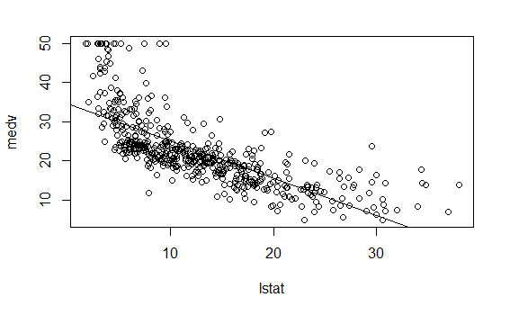

```r
plot(lstat,medv)
abline(lm.fit)
```

Probá usando los argumentos **lwd** y **col** en **abline()** y **col** y **pch** en **plot()**.

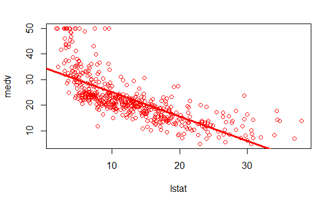

```r
plot(lstat,medv,col="red")
abline(lm.fit,lwd=3,col="red")
```

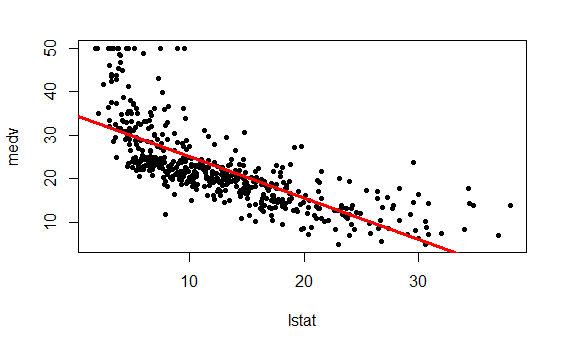

```r
plot(lstat,medv,pch=20)
abline(lm.fit,lwd=3,col="red")
```

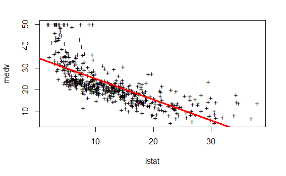

```r
plot(lstat,medv,pch="+")
abline(lm.fit,lwd=3,col="red")
```

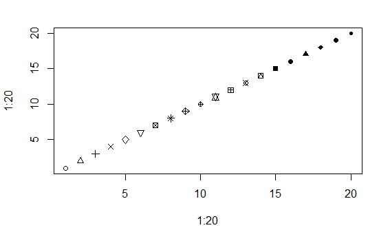

```r
plot(1:20,1:20,pch=1:20)
```

Usá **plot()** con **lm.fit()**.

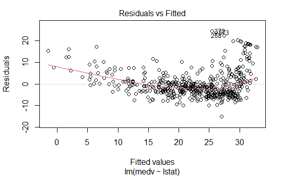

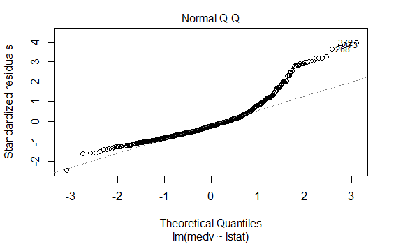

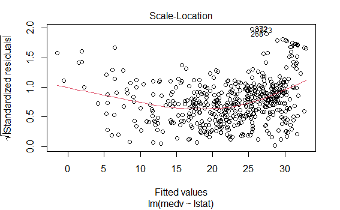

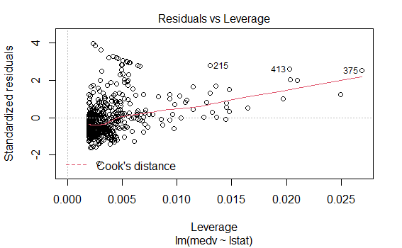

```r
plot(lm.fit)
```

## Regresión lineal múltiple

Ahora, generá un modelo usando todos los predictores disponibles, teniendo a **medv** como variable dependiente.

```r
lm.fit=lm(medv∼.,data=Boston )
summary(lm.fit)
```

```
Call:
lm(formula = medv ~ ., data = Boston)

Residuals:
    Min      1Q  Median      3Q     Max
-15.595  -2.730  -0.518   1.777  26.199

Coefficients:
              Estimate Std. Error t value Pr(>|t|)
(Intercept)  3.646e+01  5.103e+00   7.144 3.28e-12 ***
crim        -1.080e-01  3.286e-02  -3.287 0.001087 **
zn           4.642e-02  1.373e-02   3.382 0.000778 ***
indus        2.056e-02  6.150e-02   0.334 0.738288
chas         2.687e+00  8.616e-01   3.118 0.001925 **
nox         -1.777e+01  3.820e+00  -4.651 4.25e-06 ***
rm           3.810e+00  4.179e-01   9.116  < 2e-16 ***
age          6.922e-04  1.321e-02   0.052 0.958229
dis         -1.476e+00  1.995e-01  -7.398 6.01e-13 ***
rad          3.060e-01  6.635e-02   4.613 5.07e-06 ***
tax         -1.233e-02  3.760e-03  -3.280 0.001112 **
ptratio     -9.527e-01  1.308e-01  -7.283 1.31e-12 ***
black        9.312e-03  2.686e-03   3.467 0.000573 ***
lstat       -5.248e-01  5.072e-02 -10.347  < 2e-16 ***
---
Signif. codes:  0 ‘***’ 0.001 ‘**’ 0.01 ‘*’ 0.05 ‘.’ 0.1 ‘ ’ 1

Residual standard error: 4.745 on 492 degrees of freedom
Multiple R-squared:  0.7406,    Adjusted R-squared:  0.7338
F-statistic: 108.1 on 13 and 492 DF,  p-value: < 2.2e-16
```

Usando la función **vif()** del paquete **car** podemos calcular el factor de inflación de la varianza.

```r
install.packages("car")
library(car)
```

```r
vif(lm.fit)
```

```
    crim       zn    indus     chas      nox       rm      age
1.792192 2.298758 3.991596 1.073995 4.393720 1.933744 3.100826
     dis      rad      tax  ptratio    black    lstat
3.955945 7.484496 9.008554 1.799084 1.348521 2.941491
```

## Términos de interacción

Imprimí en la consola el resultado de pasarle a **summary()** un modelo lineal que tenga como variable dependiente a **medv** y las variables **age**, **lstat** y el término de interacción de **lstat X age** como predictores.

```r
summary(lm(medv∼lstat *age ,data=Boston ))
```

```
Call:
lm(formula = medv ~ lstat * age, data = Boston)

Residuals:
    Min      1Q  Median      3Q     Max
-15.806  -4.045  -1.333   2.085  27.552

Coefficients:
              Estimate Std. Error t value Pr(>|t|)
(Intercept) 36.0885359  1.4698355  24.553  < 2e-16 ***
lstat       -1.3921168  0.1674555  -8.313 8.78e-16 ***
age         -0.0007209  0.0198792  -0.036   0.9711
lstat:age    0.0041560  0.0018518   2.244   0.0252 *
---
Signif. codes:  0 ‘***’ 0.001 ‘**’ 0.01 ‘*’ 0.05 ‘.’ 0.1 ‘ ’ 1

Residual standard error: 6.149 on 502 degrees of freedom
Multiple R-squared:  0.5557,    Adjusted R-squared:  0.5531
F-statistic: 209.3 on 3 and 502 DF,  p-value: < 2.2e-16
```

## Predictores cualitativos

Vamos a utiliar el dataset **Carseats** de la libería **ISLR**. Intentaremos predecir **Sales** (ventas de sillas para niñas y niños) en 400 locaciones basadas en un número determinado de predictores.

```r
fix(Carseats)
names(Carseats)
```

```
 [1] "Sales"       "CompPrice"   "Income"      "Advertising"
 [5] "Population"  "Price"       "ShelveLoc"   "Age"
 [9] "Education"   "Urban"       "US"
```

**Shelvloc** es un predictor cualitativo que hace referencia a la calidad (buena, mediana y mala) de la ubicación de un asiento de automóvil en un aparador de una tienda determinada.

Dada una variable cualitativa como **Shelvloc**, *R* genera variables ficticias (*dummy variables*) automáticamente.

Vamos a realizar una regresión lineal múltiple que incluya algunos términos de interacción.

```r
lm.fit=lm(Sales∼.+ Income :Advertising +Price :Age ,data=Carseats )
summary(lm.fit)
```

```
Call:
lm(formula = Sales ~ . + Income:Advertising + Price:Age, data = Carseats)

Residuals:
    Min      1Q  Median      3Q     Max
-2.9208 -0.7503  0.0177  0.6754  3.3413

Coefficients:
                     Estimate Std. Error t value Pr(>|t|)
(Intercept)         6.5755654  1.0087470   6.519 2.22e-10 ***
CompPrice           0.0929371  0.0041183  22.567  < 2e-16 ***
Income              0.0108940  0.0026044   4.183 3.57e-05 ***
Advertising         0.0702462  0.0226091   3.107 0.002030 **
Population          0.0001592  0.0003679   0.433 0.665330
Price              -0.1008064  0.0074399 -13.549  < 2e-16 ***
ShelveLocGood       4.8486762  0.1528378  31.724  < 2e-16 ***
ShelveLocMedium     1.9532620  0.1257682  15.531  < 2e-16 ***
Age                -0.0579466  0.0159506  -3.633 0.000318 ***
Education          -0.0208525  0.0196131  -1.063 0.288361
UrbanYes            0.1401597  0.1124019   1.247 0.213171
USYes              -0.1575571  0.1489234  -1.058 0.290729
Income:Advertising  0.0007510  0.0002784   2.698 0.007290 **
Price:Age           0.0001068  0.0001333   0.801 0.423812
---
Signif. codes:  0 ‘***’ 0.001 ‘**’ 0.01 ‘*’ 0.05 ‘.’ 0.1 ‘ ’ 1

Residual standard error: 1.011 on 386 degrees of freedom
Multiple R-squared:  0.8761,    Adjusted R-squared:  0.8719
F-statistic:   210 on 13 and 386 DF,  p-value: < 2.2e-16
```

La función **contrasts()** devuelve el código de la *dummy variable* que *R* generó.

```r
attach(Carseats)
contrasts(ShelveLoc)
```

```
       Good Medium
Bad       0      0
Good      1      0
Medium    0      1
```